# Assignment2: Neural Network

In this assignment, you are required to implement a **fully connected neural network** (using NumPy) to perform image classification on the MNIST dataset.

## Set up the environment and data

```python
import os
import sys
sys.path.append("../../homework/")

import matplotlib.pyplot as plt
import numpy as np

%load_ext autoreload
%autoreload 2

def rel_error(x, y):
    """ returns relative error """
    return np.max(np.abs(x - y) / (np.maximum(1e-8, np.abs(x) + np.abs(y))))

# Load the MNIST data and flatten it
mnist_dir = "../data/"

from data.mnist import load_from_pickle
data = load_from_pickle(os.path.join(mnist_dir + 'mnist.pkl'))

trainX, trainy = data['trainX'], data['trainy']
testX, testy = data['testX'], data['testy']

trainX = trainX.reshape(len(trainX), -1).astype('int')
testX = testX.reshape(len(testX), -1).astype('int')
```

## Fully Connected Network

Next, you are first going to design, debug & implement a neural network with fully-connected layers to perform classification using the following "toy data". Following this, you will test the neural network on the MNIST dataset.

```python
# First, create a small neural network and use the “toy data” below to verify its functionality.
# Note that the random seed is set to ensure that the experiments are repeatable

from network import Net

input_size = 4
hidden_size = 10
num_classes = 3
num_inputs = 5

def init_toy_model():
    np.random.seed(0)
    return Net(input_size, hidden_size, num_classes, std=1e-1)

def init_toy_data():
    np.random.seed(1)
    X = 10 * np.random.randn(num_inputs, input_size)
    y = np.array([0, 1, 2, 2, 1])
    return X, y

net = init_toy_model()
X, y = init_toy_data()
```

### Forward pass: Compute scores

Open the file `homework/Assignment2/network.py` and carefully look at the class method `Net.loss` which uses the data and weights to compute the class scores, the loss, and the gradients. Complete the "compute the score" part which uses the weights and biases to compute the scores for all inputs in the forward pass and then run the cell below to verify your implementation.

```python
scores = net.loss(X)
print('Your scores:')
print(scores)

print('\n correct scores:')
correct_scores = np.asarray([
  [-0.81233741, -1.27654624, -0.70335995],
  [-0.17129677, -1.18803311, -0.47310444],
  [-0.51590475, -1.01354314, -0.8504215 ],
  [-0.15419291, -0.48629638, -0.52901952],
  [-0.00618733, -0.12435261, -0.15226949]])
print(correct_scores)

# The difference should be very small;  < 1e-7
print('\n Difference between your scores and correct scores:')
print(np.sum(np.abs(scores - correct_scores)))
```

```
Your scores:
[[-0.81233741 -1.27654624 -0.70335995]
 [-0.17129677 -1.18803311 -0.47310444]
 [-0.51590475 -1.01354314 -0.8504215 ]
 [-0.15419291 -0.48629638 -0.52901952]
 [-0.00618733 -0.12435261 -0.15226949]]

 correct scores:
[[-0.81233741 -1.27654624 -0.70335995]
 [-0.17129677 -1.18803311 -0.47310444]
 [-0.51590475 -1.01354314 -0.8504215 ]
 [-0.15419291 -0.48629638 -0.52901952]
 [-0.00618733 -0.12435261 -0.15226949]]

 Difference between your scores and correct scores:
3.6802720496109664e-08
```

### Forward pass: Compute loss

Complete the second part in the same class method `Net.loss` which computes the data and regularization loss.

```python
loss, _ = net.loss(X, y, reg=0.05)
correct_loss = 1.30378789133

# should be very small; less than 1e-12
print('Difference between your loss and correct loss:')
print(np.sum(np.abs(loss - correct_loss)))
```

```
Difference between your loss and correct loss:
0.018965419606063127
```

### Backward pass

Complete the rest of `Net.loss` (i.e., the backward pass) to compute the gradient of the loss with respect to variables `W1`, `b1`, `W2`, and `b2`. Next, debug your backward pass using the following numeric gradient check:

```python
from gradient_check import eval_numerical_gradient

# Use numeric gradient checking to check your implementation of the backward pass.
# If your implementation is correct, the difference between the numeric and
# analytic gradients should be less than 1e-8 for each of W1, W2, b1, and b2.

loss, grads = net.loss(X, y, reg=0.05)

# these differences should be less than 1e-8
for param_name in grads:
    f = lambda W: net.loss(X, y, reg=0.05)[0]
    param_grad_num = eval_numerical_gradient(f, net.params[param_name], verbose=False)
    print('%s max relative error: %e' % (param_name, rel_error(param_grad_num, grads[param_name])))
```

```
W2 max relative error: 3.440708e-09
b2 max relative error: 2.107306e-10
W1 max relative error: 3.561318e-09
b1 max relative error: 1.555470e-09
```

### Training the network using Stochastic Gradient Descent (SGD)

Complete the missing sections in class methods `Net.train` and `Net.predict` to implement the training and prediction procedures, respectively.

Next, run the code below to train a two-layer network on "toy data". Take note of the training loss, which should be less than 0.2.

```
Final training loss:  0.017143645815455258
```

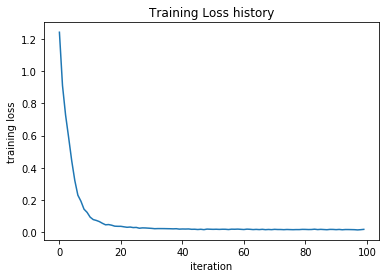

```python
net = init_toy_model()
stats = net.train(X, y, X, y,
            learning_rate=1e-1, reg=5e-6,
            num_iters=100, verbose=False)

print('Final training loss: ', stats['loss_history'][-1])

# plot the loss history
plt.plot(stats['loss_history'])
plt.xlabel('iteration')
plt.ylabel('training loss')
plt.title('Training Loss history')
plt.show()
```

Now that you have now implemented a two-layer network tested using the "toy data", you should next train & test it on a real dataset such as the MNIST data. Run the code below to train your network using SGD and an adaptive learning rate schedule as the optimization proceeds, then test it on a validation set. After each epoch, reduce the learning rate by multiplying it by a decay rate.

```python
X_train, X_val = trainX[:50000], trainX[50000:]
y_train, y_val = trainy[:50000], trainy[50000:]

input_size = 28 * 28
hidden_size = 50
num_classes = 10
net = Net(input_size, hidden_size, num_classes)

# Train the network
stats = net.train(X_train, y_train, X_val, y_val,
            num_iters=10000, batch_size=128,
            learning_rate=1e-4, learning_rate_decay=0.95,
            reg=0.25, verbose=True)

# Predict on the validation set
val_acc = (net.predict(X_val) == y_val).mean()
print('Validation accuracy: ', val_acc)
```

```
iteration 0 / 10000: loss 2.302620
iteration 1000 / 10000: loss 0.660341
iteration 2000 / 10000: loss 0.420409
iteration 3000 / 10000: loss 0.505560
iteration 4000 / 10000: loss 0.325660
iteration 5000 / 10000: loss 0.334534
iteration 6000 / 10000: loss 0.279986
iteration 7000 / 10000: loss 0.268011
iteration 8000 / 10000: loss 0.280374
iteration 9000 / 10000: loss 0.201946
Validation accuracy:  0.9451
```

### Tune your network

Complete the code block below to tune your network on the validation set. You may use the cross validation method discussed in Assignment1.

```python
best_net = None # store the best model into this
best_acc=0
#################################################################################
# TODO: Tune hyperparameters using the validation set. Store your best trained  #
# model in best_net.                                                            #
#################################################################################
input_size = 28*28
num_classes = 10

# Train the network
for batch_size in [200, 400,800]:
    for learningrate in [1e-2, 1e-3, 1e-4]:
        for hidden_size in [50, 100, 200]:
            net = Net(input_size, hidden_size, num_classes)
            stats = net.train(X_train, y_train, X_val, y_val,num_iters=2000, batch_size=batch_size,learning_rate=learningrate, learning_rate_decay=0.93,reg=0.5, verbose=True)
            # validation set：prediction
            val_acc = (net.predict(X_val) == y_val).mean()
            print('batchsize selection = %d, hidden size = %f, lr = %f, Valid_accuracy: %f' %(batch_size, hidden_size,learningrate,val_acc))
            if val_acc > best_acc:
                best_acc = val_acc
                best_net = net
#################################################################################
#                               END OF YOUR CODE                                #
#################################################################################
```

```
iteration 0 / 2000: loss 2.302668
iteration 1000 / 2000: loss 2.308260
batchsize selection = 200, hidden size = 50.000000, lr = 0.010000, Valid_accuracy: 0.106400
iteration 0 / 2000: loss 2.302783
iteration 1000 / 2000: loss 2.016017
batchsize selection = 200, hidden size = 100.000000, lr = 0.010000, Valid_accuracy: 0.217000
iteration 0 / 2000: loss 2.303040
iteration 1000 / 2000: loss 2.029922
batchsize selection = 200, hidden size = 200.000000, lr = 0.010000, Valid_accuracy: 0.214800
iteration 0 / 2000: loss 2.302708
iteration 1000 / 2000: loss 0.290783
batchsize selection = 200, hidden size = 50.000000, lr = 0.001000, Valid_accuracy: 0.953000
iteration 0 / 2000: loss 2.302768
iteration 1000 / 2000: loss 0.354617
batchsize selection = 200, hidden size = 100.000000, lr = 0.001000, Valid_accuracy: 0.955000
iteration 0 / 2000: loss 2.303002
iteration 1000 / 2000: loss 0.364971
batchsize selection = 200, hidden size = 200.000000, lr = 0.001000, Valid_accuracy: 0.958700
iteration 0 / 2000: loss 2.302680
iteration 1000 / 2000: loss 0.650925
batchsize selection = 200, hidden size = 50.000000, lr = 0.000100, Valid_accuracy: 0.885100
iteration 0 / 2000: loss 2.302819
iteration 1000 / 2000: loss 0.675196
batchsize selection = 200, hidden size = 100.000000, lr = 0.000100, Valid_accuracy: 0.889100
iteration 0 / 2000: loss 2.302998
iteration 1000 / 2000: loss 0.647257
batchsize selection = 200, hidden size = 200.000000, lr = 0.000100, Valid_accuracy: 0.892800
iteration 0 / 2000: loss 2.302681
iteration 1000 / 2000: loss 2.300718
batchsize selection = 400, hidden size = 50.000000, lr = 0.010000, Valid_accuracy: 0.106400
iteration 0 / 2000: loss 2.302779
iteration 1000 / 2000: loss 2.078232
batchsize selection = 400, hidden size = 100.000000, lr = 0.010000, Valid_accuracy: 0.211500
iteration 0 / 2000: loss 2.302977
iteration 1000 / 2000: loss 2.303991
batchsize selection = 400, hidden size = 200.000000, lr = 0.010000, Valid_accuracy: 0.204800
iteration 0 / 2000: loss 2.302686
iteration 1000 / 2000: loss 0.297629
batchsize selection = 400, hidden size = 50.000000, lr = 0.001000, Valid_accuracy: 0.949400
iteration 0 / 2000: loss 2.302769
```

[output cut: 26 more lines]

```
iteration 0 / 2000: loss 2.302772
iteration 1000 / 2000: loss 0.268659
batchsize selection = 800, hidden size = 100.000000, lr = 0.001000, Valid_accuracy: 0.952500
iteration 0 / 2000: loss 2.302979
iteration 1000 / 2000: loss 0.329493
batchsize selection = 800, hidden size = 200.000000, lr = 0.001000, Valid_accuracy: 0.952300
iteration 0 / 2000: loss 2.302670
iteration 1000 / 2000: loss 0.804767
batchsize selection = 800, hidden size = 50.000000, lr = 0.000100, Valid_accuracy: 0.869500
iteration 0 / 2000: loss 2.302813
iteration 1000 / 2000: loss 0.827428
batchsize selection = 800, hidden size = 100.000000, lr = 0.000100, Valid_accuracy: 0.872900
iteration 0 / 2000: loss 2.302983
iteration 1000 / 2000: loss 0.710556
batchsize selection = 800, hidden size = 200.000000, lr = 0.000100, Valid_accuracy: 0.877700
```

### Run on the test set

Finally, evaluate your final trained network on the test set.

```python
test_acc = (best_net.predict(testX) == testy).mean()
print('Test accuracy: ', test_acc)
```

```
Test accuracy:  0.9558
```